# DGP Dossier: synth_heavytail

## 1. Identity & Status

| DGP ID | synth_heavytail |
| --- | --- |
| Version | 1.6.0 |
| Status | stable |
| Difficulty | ★★★☆☆ (3/5) |
| Stress Profile | overlap: moderatenoise: heavylinearity: lineareffect: lineartarget: both |

## 2. What This DGP Stresses (Intent)

**Purpose:** Penalize estimators that rely on L2 loss under heavy-tailed noise.

This DGP is identical to the baseline linear design except for the outcome noise, which is a Gaussian/Cauchy mixture. The Cauchy component makes the population mean of observed outcomes undefined, so any estimator that minimizes squared error is theoretically ill-posed and will suffer variance explosion.

This motivates robust estimators (e.g., median/quantile targets) that remain well-defined under heavy tails.

## 3. Identification Assumptions (Explicit)

- Unconfoundedness holds by construction (treatment is assigned by a known propensity score).
- Overlap is moderate (`p(X)` bounded away from 0 and 1 for most of the mass).
- Structural ATT is defined as the mean of the signal `tau(X)` on treated units (Constitution Article I), independent of realized noise.

## 4. Mathematical Specification

**Covariates**
$$X \sim \mathcal{N}(0, I_5)$$

**Propensity**
$$p(X) = \text{expit}(0.5 X_1 - 0.5 X_2)$$

**Baseline Outcome and Treatment Effect**
$$\mu_0(X) = 1 + X_1 + 0.5 X_2$$
$$\tau(X) = 1 + 0.5 X_1$$

**Noise Mixture (Heavy Tails)**
$$\varepsilon \sim 0.8 \cdot \mathcal{N}(0, 0.5^2) + 0.2 \cdot
\text{Cauchy}(0, 1)$$
where $\varepsilon_0$ and $\varepsilon_1$ are drawn independently.

**Moment note:** The Cauchy component has undefined mean and variance. Therefore the population mean of realized outcomes is undefined, and any L2/MSE estimator is not well-posed in the population.

**Potential Outcomes**
$$Y_0 = \mu_0(X) + \varepsilon_0,\quad
Y_1 = \mu_0(X) + \tau(X) + \varepsilon_1$$

## 5. Oracle Truth Definition

- **ATT (Structural):** $\mathbb{E}[\tau(X) \mid W=1]$, computed from the deterministic signal $\tau(X)$. This is well-defined even when $\mathbb{E}[Y]$ is not.
- **QST (Distributional):** computed on the canonical tau grid via oracle Monte Carlo as specified in `cs_get_oracle_qst()`.

## 6. Visual Diagnostics (n = 5000)

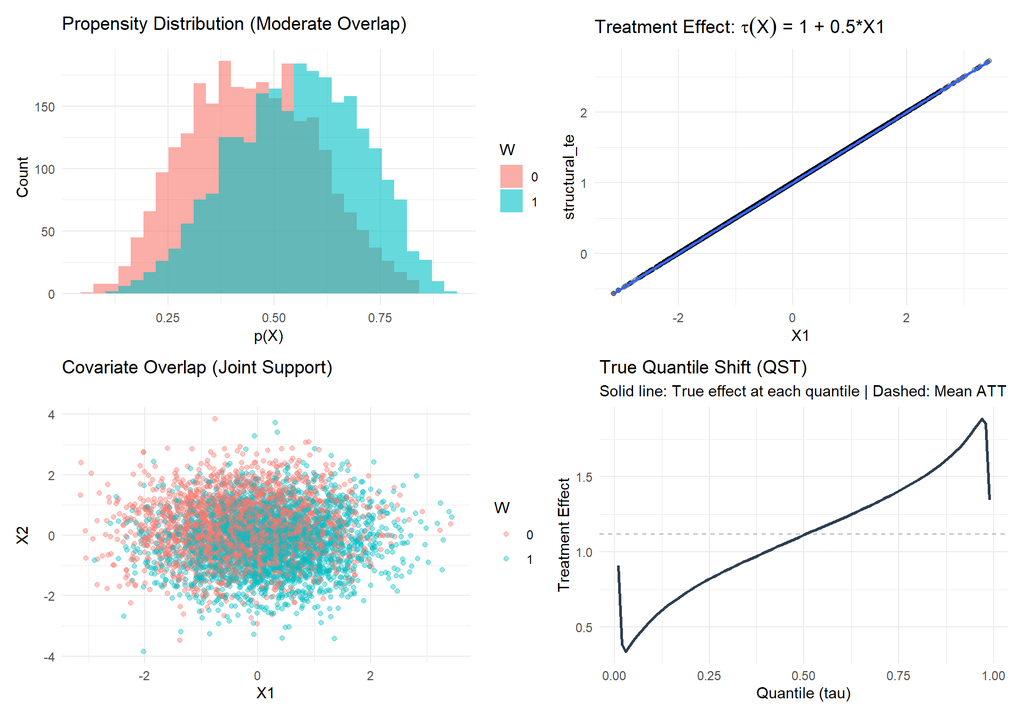

## 7. Empirical Validation

We run light validation with `n = 1000` and `seeds = 1:20`. The goal is to show variance explosion for OLS under L2 loss. We do **not** run heavier robust estimators here to keep doc builds fast.

Empirical validation (n=1000, seeds=1:20)

| estimator_id | mean_bias | rmse |
| --- | --- | --- |
| lm_att | 3.801 | 9.684 |
| oracle_att | 0.000 | 0.000 |

## 8. Failure Mode Summary

- **L2-based estimators (OLS/IPW with mean targets):** variance explosion; unstable RMSE.
- **Robust estimators (median/quantile targets):** well-defined under heavy tails.

## 9. Implementation Reference

- Generator: `R/dgp-synth-heavytail.R`
- Oracle truth: `cs_get_oracle_qst("synth_heavytail", version = "1.6.0")`
- Metadata: `inst/dgp_meta/synth_heavytail.yml`

## 11. Changelog

- v1.3.0 (2026-01-06): Initial dossier for heavy-tail stress DGP.
- v1.6.0: Implemented Common Random Numbers (CRN) for Oracle generation. Eliminates Monte Carlo noise in QST truth benchmarks. Also enforces regime consistency (Normal/Cauchy) for counterfactuals during Oracle evaluation.

## Appendix: Implementation

```
Source code for: dgp_synth_heavytail_v160

function(n, seed = NULL, include_truth = TRUE, oracle_only = FALSE) {
  if (!is.null(seed)) {
    cs_set_rng(seed)
  }

  X1 <- stats::rnorm(n, mean = 0, sd = 1)
  X2 <- stats::rnorm(n, mean = 0, sd = 1)
  if (!isTRUE(oracle_only)) {
    X3 <- stats::rnorm(n, mean = 0, sd = 1)
    X4 <- stats::rnorm(n, mean = 0, sd = 1)
    X5 <- stats::rnorm(n, mean = 0, sd = 1)
  }

  mu0 <- 1 + X1 + 0.5 * X2
  tau <- 1 + 0.5 * X1
  p <- stats::plogis(0.5 * X1 - 0.5 * X2)

  w <- stats::rbinom(n, size = 1, prob = p)

  mix_ind0 <- stats::rbinom(n, size = 1, prob = 0.8)
  eps0 <- ifelse(
    mix_ind0 == 1L,
    stats::rnorm(n, mean = 0, sd = 0.5),
    stats::rcauchy(n, location = 0, scale = 1)
  )

  if (isTRUE(oracle_only)) {
    # CRN: Lock error term to eliminate MC variance and regime mismatch
    eps1 <- eps0
  } else {
    mix_ind1 <- stats::rbinom(n, size = 1, prob = 0.8)
    eps1 <- ifelse(
      mix_ind1 == 1L,
      stats::rnorm(n, mean = 0, sd = 0.5),
      stats::rcauchy(n, location = 0, scale = 1)
    )
  }

```

[output cut: 27 more lines]

```
    meta = list(
      dgp_id        = "synth_heavytail",
      version       = "1.6.0",
      type          = "synthetic",
      params        = list(n = n, seed = seed),
      structural_te = tau
    )
  )

  cs_check_dgp_synthetic(out)

  out
}
<bytecode: 0x000001d55381ac48>
<environment: namespace:CausalStress>
```